# Course 5 Project 1

Aharon

7/23/2020

## Course 5 Project 1

We'll begin by pulling in the necessary libraries

```r
library(tidyverse)
library(lubridate)
```

### Step 1

First, we pull in the data (and do a little date transformation for good measure)

```r
data <- read.csv("Course5Project1/activity.csv")

data$date <- ymd(data$date)
```

### Step 2

Here, the goal is to summarize by total steps per day. We can use DPLYR's group_by function to group by date, allowing us to take a sum for each day

```r
data2 <- data %>%
      group_by(date) %>%
      summarize(steps = sum(steps, na.rm = TRUE))
```

Next we visualize

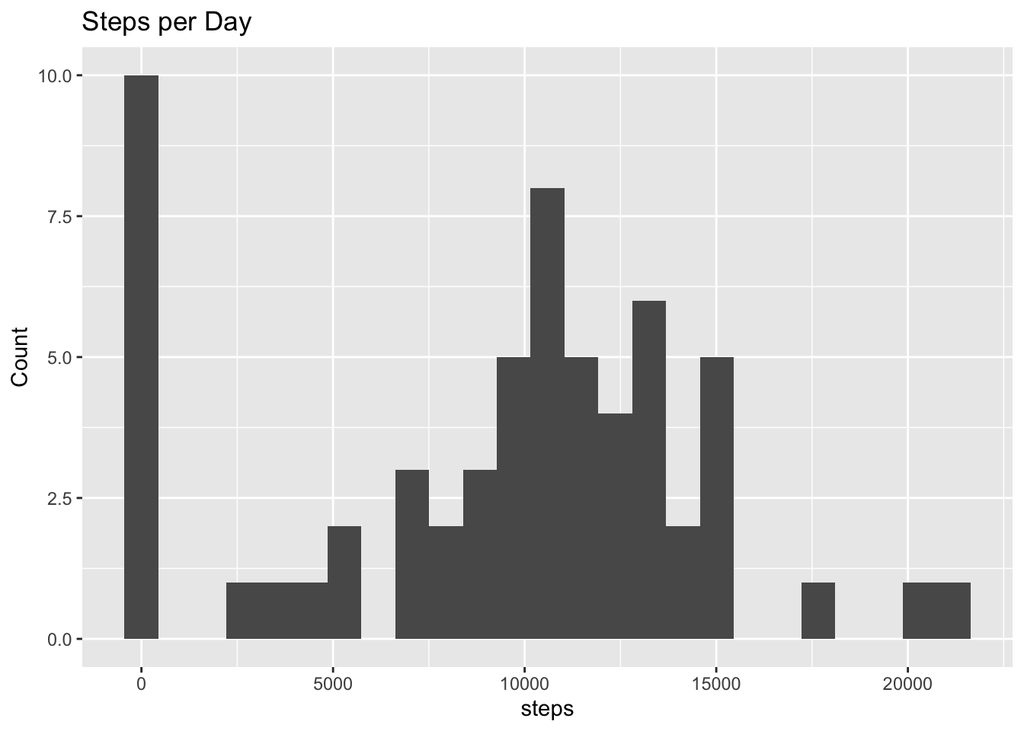

```r
ggplot(data2, aes(x = data2$steps)) +
      geom_histogram(bins = 25) +
      labs(x = "steps", y = "Count", title = "Steps per Day")
```

### Step 3

And now it's time to summarize by the mean and median steps per day. Once again, group_by and summarize are our friends.

```r
data3 <- data %>%
      group_by(date) %>%
      summarize(mean_steps =mean(steps, na.rm = TRUE) ,
                median_steps = median(steps, na.rm = TRUE))
```

And what answer do we get?

```r
print(data3)
```

```
## # A tibble: 61 x 3
##    date       mean_steps median_steps
##    <date>          <dbl>        <dbl>
##  1 2012-10-01    NaN               NA
##  2 2012-10-02      0.438            0
##  3 2012-10-03     39.4              0
##  4 2012-10-04     42.1              0
##  5 2012-10-05     46.2              0
##  6 2012-10-06     53.5              0
##  7 2012-10-07     38.2              0
##  8 2012-10-08    NaN               NA
##  9 2012-10-09     44.5              0
## 10 2012-10-10     34.4              0
## # … with 51 more rows
```

### Step 4

Now we've gotta do a time series plot, so, once again, we use group_by to do the heavy lifting.

```r
data4 <- data %>%
      group_by(interval) %>%
      summarize(mean_steps =mean(steps, na.rm = TRUE) ,
                median_steps = median(steps, na.rm = TRUE))
```

And then we visualize

[figure not shown]

```r
ggplot(data4, aes(x = interval, y = mean_steps)) +
      geom_line() +
      labs(x = "Time Interval", y = "Mean Steps", title = "Mean Steps per Day")
```

### Step 5

```r
data5 <- data %>%
      group_by(interval) %>%
      summarize(mean = mean(steps, na.rm = TRUE))
```

```r
print(data5 %>%
      filter(mean == max(data4$mean)))
```

```
## # A tibble: 0 x 2
## # … with 2 variables: interval <int>, mean <dbl>
```

### Step 6

Ooh imputation. Intimidating. But, with some quick tricks and a forloop, it shouldn't be too much trouble. Our strategy is to take average for each interval and impute that into the period in question

```r
colSums(is.na(data))
```

```
##    steps     date interval
##     2304        0        0
```

```r
data.imputed <- data

for (i in 1:length(data.imputed$steps)) {
      if (is.na(data.imputed$steps[i]) == TRUE) {
            data.imputed$steps[i] <- mean(
                  (data.imputed %>%
                         filter(interval == data.imputed[i,3]) %>%
                         select(steps))$steps,
                  na.rm = TRUE
            )
      }
}
```

Nice!

### Step 7

And next, of course, we visualize

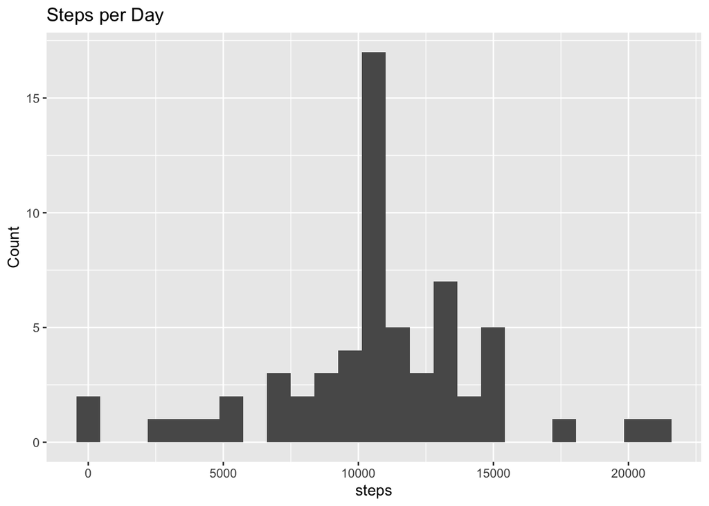

```r
data2.imputed <- data.imputed %>%
      group_by(date) %>%
      summarize(steps = sum(steps, na.rm = TRUE))

ggplot(data2.imputed, aes(x = data2.imputed$steps)) +
      geom_histogram(bins = 25) +
      labs(x = "steps", y = "Count", title = "Steps per Day")
```

### Step 8

Now, a simple panel plot comparing the average number of steps taken per 5-minute interval across weekdays and weekends. This is going to take a little extra wrangling, but not a huge deal.

```r
data_final <- data.imputed %>%
      mutate(weekday = weekdays(data.imputed$date)) %>%
      mutate(weekend = ifelse(weekdays(data.imputed$date) %in% c("Sunday", "Saturday"), "Weekend", "Weekday")) %>%
      group_by(interval, weekend) %>%
      summarize(mean(steps))

names(data_final)[3] <- "steps"
```

But now we visualize

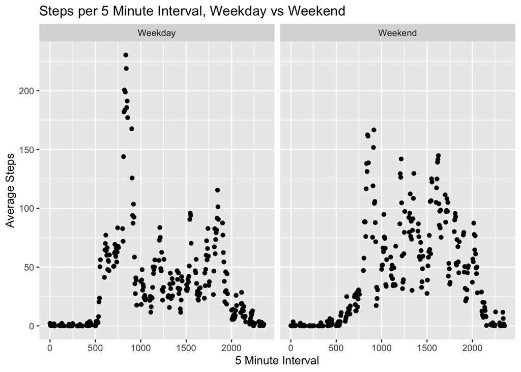

```r
ggplot(data_final, aes(x=interval, y=steps)) +
      geom_point() +
      facet_grid(cols = vars(weekend)) +
      labs(y ="Average Steps", x= "5 Minute Interval", title = "Steps per 5 Minute Interval, Weekday vs Weekend")
```

And voila, we're done!